# İkinci El Araç Fiyat Tahmini — Regresyon Projesi

**Hedef değişken:** `fiyat` (TL cinsinden sürekli değer)

**Proje adımları:**

1. Keşifsel Veri Analizi (EDA)
2. Veri Temizleme ve Ayrıştırma (Parse)
3. Özellik Mühendisliği
4. Train / Test Ayrımı
5. Ön-işleme Pipeline'ı
6. Baseline ve Gelişmiş Modeller
7. Değerlendirme (MAE, RMSE, R²)
8. Özellik Önemi ve Hata Analizi

```python
import numpy as np
import pandas as pd
import matplotlib.pyplot as plt
import seaborn as sns
from sklearn.model_selection import train_test_split, cross_val_score
from sklearn.pipeline import Pipeline
from sklearn.compose import ColumnTransformer
from sklearn.preprocessing import OneHotEncoder, StandardScaler, OrdinalEncoder
from sklearn.impute import SimpleImputer
from sklearn.linear_model import Ridge, ElasticNet
from sklearn.ensemble import RandomForestRegressor, HistGradientBoostingRegressor
from sklearn.dummy import DummyRegressor
from sklearn.metrics import mean_absolute_error, root_mean_squared_error, r2_score
import warnings, re

warnings.filterwarnings("ignore")
sns.set_theme(style="whitegrid")
pd.set_option("display.max_columns", 30)
print("Kütüphaneler yüklendi.")
```

```
Kütüphaneler yüklendi.
```

## 1. Veri Yükleme ve İlk Bakış

```python
df = pd.read_csv("cars.csv", encoding="utf-8")
print(f"Boyut: {df.shape[0]} satır × {df.shape[1]} sütun")
df.head(3)
```

```
Boyut: 52256 satır × 23 sütun
```

|  | baslik | konum | fiyat | ilan_tarihi | marka | seri | model | yil | kilometre | vites_tipi | yakit_tipi | kasa_tipi | renk | motor_hacmi | motor_gucu | cekis | arac_durumu | ortalama_yakit_tuketimi | yakit_deposu | boya_degisen | takasa_uygun | kimden | tramer |
| --- | --- | --- | --- | --- | --- | --- | --- | --- | --- | --- | --- | --- | --- | --- | --- | --- | --- | --- | --- | --- | --- | --- | --- |
| 0 | 2022 MEGANE 1.3 TCE 140 HP JOY COMFORT EDC SER... | Yeni Mh. Sarıçam, Adana | 1.169.000 TL | 21 Ağustos 2025 | Renault | Megane | 1.3 TCe Joy Comfort | 2022 | 124.000 km | Otomatik | Benzin | Sedan | Beyaz | 1201 - 1400 cm3 | 126 - 150 HP | Önden Çekiş | İkinci El | NaN | NaN | 1 değişen | Takasa Uygun | Galeriden | 71300.0 |
| 1 | 2022 SKODA OCTAVİA 1.0 E-TEC ELİTE DSG SERVİS ... | Yeni Mh. Sarıçam, Adana | 1.520.000 TL | 21 Ağustos 2025 | Skoda | Octavia | 1.0 e-Tec Elite | 2022 | 99.000 km | Otomatik | Hibrit | Sedan | Gri | 1201 - 1400 cm3 | 101 - 125 HP | Önden Çekiş | İkinci El | NaN | NaN | 1 boyalı | Takasa Uygun | Galeriden | 56060.0 |
| 2 | Sahibinden HATASIZ BOYASIZ Peugeot 207 | Cemalpaşa Mh. Seyhan, Adana | 469.999 TL | 19 Ağustos 2025 | Peugeot | 207 | 1.4 Trendy | 2009 | 207.500 km | Düz | LPG & Benzin | Hatchback/5 | Gri | 1360 cc | 91 hp | Önden Çekiş | İkinci El | 6,3 lt | 50 lt | Tamamı orjinal | Takasa Uygun | Sahibinden | NaN |

```python
df.info()
```

```
<class 'pandas.core.frame.DataFrame'>
RangeIndex: 52256 entries, 0 to 52255
Data columns (total 23 columns):
 #   Column                   Non-Null Count  Dtype
---  ------                   --------------  -----
 0   baslik                   52256 non-null  object
 1   konum                    52256 non-null  object
 2   fiyat                    52256 non-null  object
 3   ilan_tarihi              52256 non-null  object
 4   marka                    52256 non-null  object
 5   seri                     52256 non-null  object
 6   model                    52185 non-null  object
 7   yil                      52256 non-null  int64
 8   kilometre                52255 non-null  object
 9   vites_tipi               52244 non-null  object
 10  yakit_tipi               52256 non-null  object
 11  kasa_tipi                52252 non-null  object
 12  renk                     52254 non-null  object
 13  motor_hacmi              51103 non-null  object
 14  motor_gucu               50895 non-null  object
 15  cekis                    51163 non-null  object
 16  arac_durumu              52250 non-null  object
 17  ortalama_yakit_tuketimi  31568 non-null  object
 18  yakit_deposu             37211 non-null  object
 19  boya_degisen             52256 non-null  object
 20  takasa_uygun             34612 non-null  object
 21  kimden                   52256 non-null  object
 22  tramer                   5424 non-null   float64
dtypes: float64(1), int64(1), object(21)
memory usage: 9.2+ MB
```

## 2. Sütun Bazlı Profil: Tip, Örnek Değer, Eksik %, Benzersiz Sayı

```python
profile = pd.DataFrame({
    "dtype": df.dtypes,
    "non_null": df.notnull().sum(),
    "null_count": df.isnull().sum(),
    "null_pct": (df.isnull().sum() / len(df) * 100).round(2),
    "nunique": df.nunique(),
    "sample_value": df.iloc[0].values,
})
profile
```

|  | dtype | non_null | null_count | null_pct | nunique | sample_value |
| --- | --- | --- | --- | --- | --- | --- |
| baslik | object | 52256 | 0 | 0.00 | 37537 | 2022 MEGANE 1.3 TCE 140 HP JOY COMFORT EDC SER... |
| konum | object | 52256 | 0 | 0.00 | 9174 | Yeni Mh. Sarıçam, Adana |
| fiyat | object | 52256 | 0 | 0.00 | 3951 | 1.169.000 TL |
| ilan_tarihi | object | 52256 | 0 | 0.00 | 161 | 21 Ağustos 2025 |
| marka | object | 52256 | 0 | 0.00 | 59 | Renault |
| seri | object | 52256 | 0 | 0.00 | 423 | Megane |
| model | object | 52185 | 71 | 0.14 | 2951 | 1.3 TCe Joy Comfort |
| yil | int64 | 52256 | 0 | 0.00 | 54 | 2022 |
| kilometre | object | 52255 | 1 | 0.00 | 4802 | 124.000 km |
| vites_tipi | object | 52244 | 12 | 0.02 | 3 | Otomatik |
| yakit_tipi | object | 52256 | 0 | 0.00 | 5 | Benzin |
| kasa_tipi | object | 52252 | 4 | 0.01 | 11 | Sedan |
| renk | object | 52254 | 2 | 0.00 | 24 | Beyaz |
| motor_hacmi | object | 51103 | 1153 | 2.21 | 254 | 1201 - 1400 cm3 |
| motor_gucu | object | 50895 | 1361 | 2.60 | 203 | 126 - 150 HP |
| cekis | object | 51163 | 1093 | 2.09 | 5 | Önden Çekiş |
| arac_durumu | object | 52250 | 6 | 0.01 | 4 | İkinci El |
| ortalama_yakit_tuketimi | object | 31568 | 20688 | 39.59 | 89 | NaN |
| yakit_deposu | object | 37211 | 15045 | 28.79 | 51 | NaN |
| boya_degisen | object | 52256 | 0 | 0.00 | 88 | 1 değişen |
| takasa_uygun | object | 34612 | 17644 | 33.76 | 3 | Takasa Uygun |
| kimden | object | 52256 | 0 | 0.00 | 3 | Galeriden |
| tramer | float64 | 5424 | 46832 | 89.62 | 1465 | 71300.0 |

```python
print("=== Kategorik sütunlardaki benzersiz değerler (ilk 10) ===\n")
cat_cols = ["marka", "seri", "vites_tipi", "yakit_tipi", "kasa_tipi",
            "renk", "cekis", "arac_durumu", "takasa_uygun", "kimden"]
for col in cat_cols:
    vc = df[col].value_counts().head(10)
    print(f"--- {col} ({df[col].nunique()} benzersiz) ---")
    print(vc.to_string(), "\n")
```

```
=== Kategorik sütunlardaki benzersiz değerler (ilk 10) ===

--- marka (59 benzersiz) ---
marka
Renault            8563
Volkswagen         6185
Fiat               5633
Opel               5284
Ford               3756
Hyundai            2900
Toyota             2737
Peugeot            2010
BMW                1955
Mercedes - Benz    1848

--- seri (423 benzersiz) ---
seri
Astra      2686
Clio       2461
Megane     2243
Corolla    2129
Passat     2065
Focus      2035
Egea       1874
Polo       1492
Corsa      1421
Civic      1329

--- vites_tipi (3 benzersiz) ---
vites_tipi
Düz              33003
Otomatik         15351
Yarı Otomatik     3890

--- yakit_tipi (5 benzersiz) ---
yakit_tipi
Benzin          18709
Dizel           18522
LPG & Benzin    14417
Hibrit            397
```

[output cut: 39 more lines]

```
Yetkili Bayiden Sıfır           2
Yurtdışından İthal Sıfır        2
Sıfır                           1

--- takasa_uygun (3 benzersiz) ---
takasa_uygun
Takasa Uygun          23443
Takasa Uygun Değil    10696
-                       473

--- kimden (3 benzersiz) ---
kimden
Sahibinden         29137
Galeriden          22858
Yetkili Bayiden      261
```

```python
print("=== Sayısal / parse gerektiren sütunlar — örnek değerler ===\n")
for col in ["fiyat", "kilometre", "motor_hacmi", "motor_gucu",
            "ortalama_yakit_tuketimi", "yakit_deposu", "tramer", "boya_degisen"]:
    print(f"--- {col} ---")
    print(df[col].dropna().sample(min(8, df[col].dropna().shape[0]), random_state=42).values, "\n")
```

```
=== Sayısal / parse gerektiren sütunlar — örnek değerler ===

--- fiyat ---
['750.000 TL' '559.000 TL' '305.000 TL' '466.500 TL' '610.000 TL'
 '415.000 TL' '5.400.000 TL' '500.000 TL']

--- kilometre ---
['248.000 km' '215.000 km' '182.000 km' '326.000 km' '246.000 km'
 '240.000 km' '347.000 km' '188.000 km']

--- motor_hacmi ---
['1368 cc' '1596 cc' '1500 cc' '1401 - 1600 cm3' '1401 - 1600 cm3'
 '1401 - 1600 cm3' '1598 cc' '1390 cc']

--- motor_gucu ---
['125 hp' '60 hp' '126 - 150 HP' '76 - 100 HP' '76 - 100 HP'
 '101 - 125 HP' '90 hp' '122 hp']

--- ortalama_yakit_tuketimi ---
['3,4 lt' '4,9 lt' '7,7 lt' '5,6 lt' '7,7 lt' '4,7 lt' '6 lt' '5,1 lt']

--- yakit_deposu ---
['60 lt' '42 lt' '52 lt' '45 lt' '42 lt' '45 lt' '45 lt' '70 lt']

--- tramer ---
[6.20000e+03 3.18400e+03 3.75000e+05 8.20000e+01 4.30000e+02 7.10565e+05
 7.00000e+00 4.93300e+03]

--- boya_degisen ---
['2 boyalı' '2 boyalı' '4 boyalı' '1 değişen, 9 boyalı' 'Tamamı orjinal'
 '3 boyalı' 'Tamamı orjinal' 'Belirtilmemiş']
```

## 3. Eksik Veri Haritası

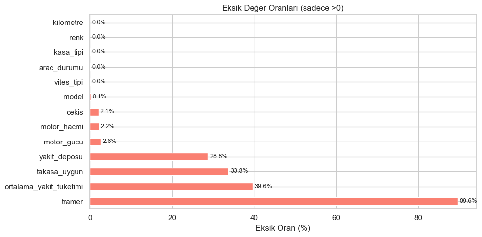

```python
null_pct = (df.isnull().sum() / len(df) * 100).sort_values(ascending=False)
null_pct = null_pct[null_pct > 0]

fig, ax = plt.subplots(figsize=(10, 5))
null_pct.plot.barh(ax=ax, color="salmon")
ax.set_xlabel("Eksik Oran (%)")
ax.set_title("Eksik Değer Oranları (sadece >0)")
for i, v in enumerate(null_pct.values):
    ax.text(v + 0.5, i, f"{v:.1f}%", va="center", fontsize=9)
plt.tight_layout()
plt.show()
```

```python
dup_count = df.duplicated(subset=["marka", "seri", "yil", "kilometre", "fiyat"]).sum()
print(f"Olası yinelenen ilan sayısı (marka+seri+yıl+km+fiyat eşleşmesi): {dup_count}")
print(f"Toplam satır: {len(df)}")
print(f"Yinelenen oran: %{dup_count / len(df) * 100:.2f}")
```

```
Olası yinelenen ilan sayısı (marka+seri+yıl+km+fiyat eşleşmesi): 378
Toplam satır: 52256
Yinelenen oran: %0.72
```

## 4. Veri Temizleme ve Ayrıştırma (Parse)

Sayısal olması gereken ama string halinde bulunan sütunları temizliyoruz:

```python
def parse_fiyat(val):
    """'1.169.000 TL' → 1169000"""
    if pd.isna(val):
        return np.nan
    s = str(val).replace(".", "").replace("TL", "").strip()
    try:
        return int(s)
    except ValueError:
        return np.nan

def parse_km(val):
    """'124.000 km' → 124000"""
    if pd.isna(val):
        return np.nan
    s = str(val).replace(".", "").replace("km", "").strip()
    try:
        return int(s)
    except ValueError:
        return np.nan

def parse_motor_hacmi(val):
    """'1368 cc' → 1368 veya '1201 - 1400 cm3' → 1300.5 (orta değer)"""
    if pd.isna(val):
        return np.nan
    s = str(val).strip()
    nums = re.findall(r"\d+", s)
    if len(nums) == 2:
        return (int(nums[0]) + int(nums[1])) / 2
    elif len(nums) == 1:
        return float(nums[0])
    return np.nan

def parse_motor_gucu(val):
    """'91 hp' → 91 veya '76 - 100 HP' → 88"""
    if pd.isna(val):
        return np.nan
    s = str(val).strip()
    nums = re.findall(r"\d+", s)
    if len(nums) == 2:
        return (int(nums[0]) + int(nums[1])) / 2
    elif len(nums) == 1:
        return float(nums[0])
    return np.nan

def parse_yakit_tuketim(val):
    """'6,3 lt' → 6.3"""
    if pd.isna(val):
        return np.nan
    s = str(val).replace(",", ".").replace("lt", "").strip()
    try:
        return float(s)
    except ValueError:
        return np.nan

def parse_yakit_deposu(val):
    """'50 lt' → 50"""
    if pd.isna(val):
        return np.nan
    s = str(val).replace("lt", "").strip()
    try:
        return int(s)
    except ValueError:
        return np.nan

def parse_boya_degisen(val):
    """Boyalı ve değişen parça sayısını çıkarır. 'Tamamı orjinal' → (0,0)"""
    boyali, degisen = 0, 0
    if pd.isna(val):
        return np.nan, np.nan
    s = str(val).lower().strip()
    if "tamamı orjinal" in s:
        return 0, 0
    if "tamamı boyalı" in s:
        return 10, 0  # tüm paneller
    if "belirtilmemiş" in s:
        return np.nan, np.nan

    m_boyali = re.search(r"(\d+)\s*boyalı", s)
    m_degisen = re.search(r"(\d+)\s*değişen", s)
    if m_boyali:
        boyali = int(m_boyali.group(1))
    if m_degisen:
        degisen = int(m_degisen.group(1))
    return boyali, degisen

print("Parse fonksiyonları tanımlandı.")
```

```
Parse fonksiyonları tanımlandı.
```

```python
df["fiyat_num"] = df["fiyat"].apply(parse_fiyat)
df["km_num"] = df["kilometre"].apply(parse_km)
df["motor_hacmi_num"] = df["motor_hacmi"].apply(parse_motor_hacmi)
df["motor_gucu_num"] = df["motor_gucu"].apply(parse_motor_gucu)
df["yakit_tuketim_num"] = df["ortalama_yakit_tuketimi"].apply(parse_yakit_tuketim)
df["yakit_deposu_num"] = df["yakit_deposu"].apply(parse_yakit_deposu)

boya_parsed = df["boya_degisen"].apply(parse_boya_degisen)
df["boyali_sayi"] = boya_parsed.apply(lambda x: x[0])
df["degisen_sayi"] = boya_parsed.apply(lambda x: x[1])

df["tramer_num"] = df["tramer"].fillna(0)

print("Parse sonrası yeni sütunlar:")
print(df[["fiyat_num", "km_num", "motor_hacmi_num", "motor_gucu_num",
          "yakit_tuketim_num", "yakit_deposu_num", "boyali_sayi",
          "degisen_sayi", "tramer_num"]].describe().round(2))
```

```
Parse sonrası yeni sütunlar:
          fiyat_num       km_num  motor_hacmi_num  motor_gucu_num  \
count  5.225600e+04     52255.00         40300.00        50777.00
mean   7.621392e+05    207655.47          1456.83          106.91
std    2.186182e+06    523298.10           300.88           37.20
min    1.000000e+04         0.00           601.50           41.00
25%    3.500000e+05    130000.00          1364.00           88.00
50%    5.782500e+05    200000.00          1490.00          100.00
75%    9.450000e+05    266000.00          1597.00          115.00
max    4.670000e+08  99999999.00          6592.00          761.00

       yakit_tuketim_num  yakit_deposu_num  boyali_sayi  degisen_sayi  \
count           31568.00          37211.00     41708.00      41708.00
mean                5.72             52.28         2.61          0.54
std                 1.36              7.55         3.30          0.91
min                 0.80             30.00         0.00          0.00
25%                 4.50             45.00         0.00          0.00
50%                 5.70             50.00         1.00          0.00
75%                 6.70             55.00         4.00          1.00
max                14.10            100.00        12.00         11.00

        tramer_num
count     52256.00
mean      26429.45
std      723638.52
min           0.00
25%           0.00
50%           0.00
75%           0.00
max    31012019.00
```

```python
print(f"Parse sonrası eksik sayıları:")
for col in ["fiyat_num", "km_num", "motor_hacmi_num", "motor_gucu_num",
            "yakit_tuketim_num", "yakit_deposu_num", "boyali_sayi", "degisen_sayi"]:
    n = df[col].isna().sum()
    print(f"  {col}: {n} ({n/len(df)*100:.2f}%)")
```

```
Parse sonrası eksik sayıları:
  fiyat_num: 0 (0.00%)
  km_num: 1 (0.00%)
  motor_hacmi_num: 11956 (22.88%)
  motor_gucu_num: 1479 (2.83%)
  yakit_tuketim_num: 20688 (39.59%)
  yakit_deposu_num: 15045 (28.79%)
  boyali_sayi: 10548 (20.19%)
  degisen_sayi: 10548 (20.19%)
```

## 5. Parse Sonrası Dağılımlar ve Görselleştirme

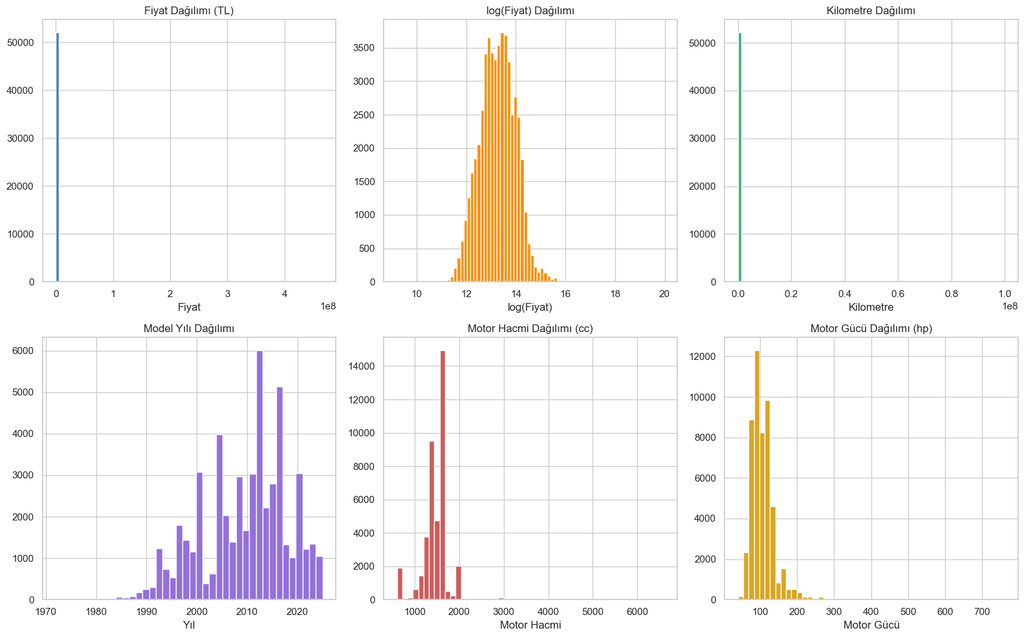

```python
fig, axes = plt.subplots(2, 3, figsize=(16, 10))

axes[0, 0].hist(df["fiyat_num"].dropna(), bins=80, color="steelblue", edgecolor="white")
axes[0, 0].set_title("Fiyat Dağılımı (TL)")
axes[0, 0].set_xlabel("Fiyat")

axes[0, 1].hist(np.log1p(df["fiyat_num"].dropna()), bins=80, color="darkorange", edgecolor="white")
axes[0, 1].set_title("log(Fiyat) Dağılımı")
axes[0, 1].set_xlabel("log(Fiyat)")

axes[0, 2].hist(df["km_num"].dropna(), bins=80, color="mediumseagreen", edgecolor="white")
axes[0, 2].set_title("Kilometre Dağılımı")
axes[0, 2].set_xlabel("Kilometre")

axes[1, 0].hist(df["yil"], bins=40, color="mediumpurple", edgecolor="white")
axes[1, 0].set_title("Model Yılı Dağılımı")
axes[1, 0].set_xlabel("Yıl")

axes[1, 1].hist(df["motor_hacmi_num"].dropna(), bins=50, color="indianred", edgecolor="white")
axes[1, 1].set_title("Motor Hacmi Dağılımı (cc)")
axes[1, 1].set_xlabel("Motor Hacmi")

axes[1, 2].hist(df["motor_gucu_num"].dropna(), bins=50, color="goldenrod", edgecolor="white")
axes[1, 2].set_title("Motor Gücü Dağılımı (hp)")
axes[1, 2].set_xlabel("Motor Gücü")

plt.tight_layout()
plt.show()
```

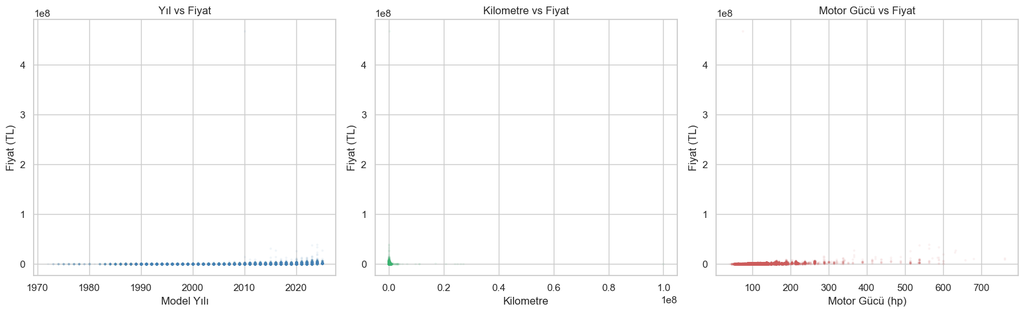

```python
fig, axes = plt.subplots(1, 3, figsize=(16, 5))

axes[0].scatter(df["yil"], df["fiyat_num"], alpha=0.05, s=3, color="steelblue")
axes[0].set_xlabel("Model Yılı")
axes[0].set_ylabel("Fiyat (TL)")
axes[0].set_title("Yıl vs Fiyat")

axes[1].scatter(df["km_num"], df["fiyat_num"], alpha=0.05, s=3, color="mediumseagreen")
axes[1].set_xlabel("Kilometre")
axes[1].set_ylabel("Fiyat (TL)")
axes[1].set_title("Kilometre vs Fiyat")

axes[2].scatter(df["motor_gucu_num"], df["fiyat_num"], alpha=0.05, s=3, color="indianred")
axes[2].set_xlabel("Motor Gücü (hp)")
axes[2].set_ylabel("Fiyat (TL)")
axes[2].set_title("Motor Gücü vs Fiyat")

plt.tight_layout()
plt.show()
```

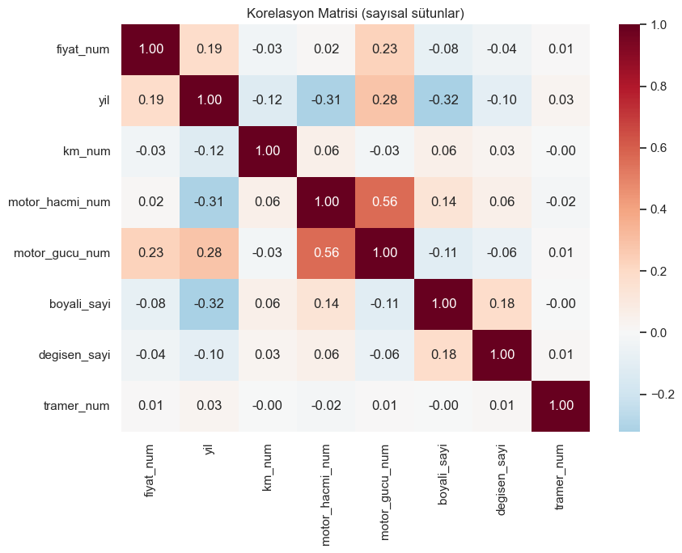

```python
num_cols = ["fiyat_num", "yil", "km_num", "motor_hacmi_num", "motor_gucu_num",
            "boyali_sayi", "degisen_sayi", "tramer_num"]
corr = df[num_cols].corr()

fig, ax = plt.subplots(figsize=(9, 7))
sns.heatmap(corr, annot=True, fmt=".2f", cmap="RdBu_r", center=0, ax=ax)
ax.set_title("Korelasyon Matrisi (sayısal sütunlar)")
plt.tight_layout()
plt.show()
```

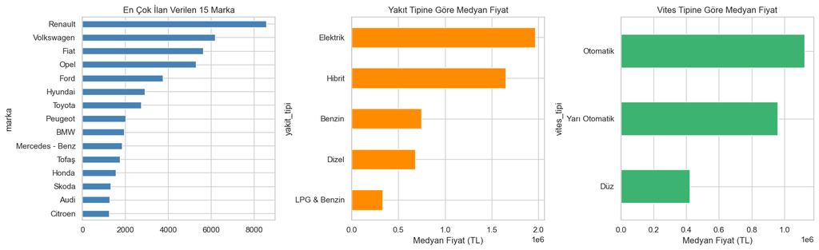

```python
fig, axes = plt.subplots(1, 3, figsize=(16, 5))

top_marka = df["marka"].value_counts().head(15)
top_marka.plot.barh(ax=axes[0], color="steelblue")
axes[0].set_title("En Çok İlan Verilen 15 Marka")
axes[0].invert_yaxis()

df.groupby("yakit_tipi")["fiyat_num"].median().sort_values().plot.barh(ax=axes[1], color="darkorange")
axes[1].set_title("Yakıt Tipine Göre Medyan Fiyat")
axes[1].set_xlabel("Medyan Fiyat (TL)")

df.groupby("vites_tipi")["fiyat_num"].median().sort_values().plot.barh(ax=axes[2], color="mediumseagreen")
axes[2].set_title("Vites Tipine Göre Medyan Fiyat")
axes[2].set_xlabel("Medyan Fiyat (TL)")

plt.tight_layout()
plt.show()
```

## 6. Özellik Seçimi ve Temiz Veri Seti Oluşturma

Modelleme için kullanılacak sütunlar:

**Sayısal:** `yil`, `km_num`, `motor_hacmi_num`, `motor_gucu_num`, `boyali_sayi`, `degisen_sayi`, `tramer_num`

**Kategorik:** `marka`, `vites_tipi`, `yakit_tipi`, `kasa_tipi`, `cekis`, `kimden`

**Hariç tutulanlar:**

- `baslik`: sızıntı riski + yüksek kardinalite
- `konum`: 9000+ benzersiz — ileri aşamada "il" çıkarılabilir
- `seri`, `model`: yüksek kardinalite; `marka` yeterli baseline için
- `arac_durumu`: neredeyse tamamı "İkinci El"
- `ortalama_yakit_tuketimi`, `yakit_deposu`: %30-40 eksik
- `takasa_uygun`: %34 eksik
- `ilan_tarihi`, `renk`: ileri aşama iyileştirme için bırakıldı

```python
numeric_features = ["yil", "km_num", "motor_hacmi_num", "motor_gucu_num",
                    "boyali_sayi", "degisen_sayi", "tramer_num"]
categorical_features = ["marka", "vites_tipi", "yakit_tipi", "kasa_tipi", "cekis", "kimden"]
target = "fiyat_num"

keep_cols = numeric_features + categorical_features + [target]
dfm = df[keep_cols].copy()

print(f"Seçilen sütunlarla boyut: {dfm.shape}")
print(f"Hedef (fiyat_num) eksik: {dfm[target].isna().sum()}")

dfm = dfm.dropna(subset=[target])
dfm = dfm[dfm[target] > 0]
print(f"Hedef NaN/0 temizliği sonrası: {dfm.shape[0]} satır")

q_low = dfm[target].quantile(0.01)
q_high = dfm[target].quantile(0.99)
before = len(dfm)
dfm = dfm[(dfm[target] >= q_low) & (dfm[target] <= q_high)]
print(f"Fiyat outlier temizliği (P1-P99): {before} → {len(dfm)} satır")
print(f"Fiyat aralığı: {dfm[target].min():,.0f} – {dfm[target].max():,.0f} TL")

cat_dash_cols = ["cekis", "kasa_tipi"]
for col in cat_dash_cols:
    dfm[col] = dfm[col].replace("-", np.nan)

print(f"\nSon boyut: {dfm.shape}")
dfm.head()
```

```
Seçilen sütunlarla boyut: (52256, 14)
Hedef (fiyat_num) eksik: 0
Hedef NaN/0 temizliği sonrası: 52256 satır
Fiyat outlier temizliği (P1-P99): 52256 → 51260 satır
Fiyat aralığı: 120,000 – 3,397,500 TL

Son boyut: (51260, 14)
```

|  | yil | km_num | motor_hacmi_num | motor_gucu_num | boyali_sayi | degisen_sayi | tramer_num | marka | vites_tipi | yakit_tipi | kasa_tipi | cekis | kimden | fiyat_num |
| --- | --- | --- | --- | --- | --- | --- | --- | --- | --- | --- | --- | --- | --- | --- |
| 0 | 2022 | 124000.0 | NaN | 138.0 | 0.0 | 1.0 | 71300.0 | Renault | Otomatik | Benzin | Sedan | Önden Çekiş | Galeriden | 1169000 |
| 1 | 2022 | 99000.0 | NaN | 113.0 | 1.0 | 0.0 | 56060.0 | Skoda | Otomatik | Hibrit | Sedan | Önden Çekiş | Galeriden | 1520000 |
| 2 | 2009 | 207500.0 | 1360.0 | 91.0 | 0.0 | 0.0 | 0.0 | Peugeot | Düz | LPG & Benzin | Hatchback/5 | Önden Çekiş | Sahibinden | 469999 |
| 3 | 2013 | 219000.0 | NaN | 188.0 | 4.0 | 1.0 | 0.0 | Audi | Otomatik | Dizel | Sedan | 4WD (Sürekli) | Galeriden | 1150000 |
| 4 | 2013 | 335000.0 | NaN | 188.0 | 0.0 | 0.0 | 0.0 | BMW | Otomatik | Benzin | Sedan | Arkadan İtiş | Galeriden | 1359000 |

## 7. Train / Test Ayrımı

```python
X = dfm[numeric_features + categorical_features]
y = dfm[target]

X_train, X_test, y_train, y_test = train_test_split(
    X, y, test_size=0.2, random_state=42
)

print(f"Train: {X_train.shape[0]} satır")
print(f"Test:  {X_test.shape[0]} satır")
print(f"Hedef ortalaması — Train: {y_train.mean():,.0f} TL | Test: {y_test.mean():,.0f} TL")
```

```
Train: 41008 satır
Test:  10252 satır
Hedef ortalaması — Train: 711,552 TL | Test: 708,901 TL
```

## 8. Ön-işleme Pipeline ve Modelleme

```python
numeric_transformer = Pipeline(steps=[
    ("imputer", SimpleImputer(strategy="median")),
    ("scaler", StandardScaler()),
])

categorical_transformer = Pipeline(steps=[
    ("imputer", SimpleImputer(strategy="most_frequent")),
    ("encoder", OneHotEncoder(handle_unknown="ignore", sparse_output=False)),
])

preprocessor = ColumnTransformer(transformers=[
    ("num", numeric_transformer, numeric_features),
    ("cat", categorical_transformer, categorical_features),
])

print("Preprocessor tanımlandı.")
print(f"  Sayısal sütunlar ({len(numeric_features)}): {numeric_features}")
print(f"  Kategorik sütunlar ({len(categorical_features)}): {categorical_features}")
```

```
Preprocessor tanımlandı.
  Sayısal sütunlar (7): ['yil', 'km_num', 'motor_hacmi_num', 'motor_gucu_num', 'boyali_sayi', 'degisen_sayi', 'tramer_num']
  Kategorik sütunlar (6): ['marka', 'vites_tipi', 'yakit_tipi', 'kasa_tipi', 'cekis', 'kimden']
```

```python
def evaluate_model(name, model, X_tr, y_tr, X_te, y_te):
    """Modeli eğit, test et, metrikleri döndür."""
    model.fit(X_tr, y_tr)
    y_pred = model.predict(X_te)
    mae = mean_absolute_error(y_te, y_pred)
    rmse = root_mean_squared_error(y_te, y_pred)
    r2 = r2_score(y_te, y_pred)
    print(f"{name:35s} | MAE: {mae:>12,.0f} | RMSE: {rmse:>12,.0f} | R²: {r2:.4f}")
    return {"model": name, "MAE": mae, "RMSE": rmse, "R2": r2, "pipeline": model}

print("evaluate_model() tanımlandı.")
```

```
evaluate_model() tanımlandı.
```

### 8a. Baseline: DummyRegressor (ortalama tahmini)

```python
results = []

dummy_pipe = Pipeline([
    ("preprocessor", preprocessor),
    ("model", DummyRegressor(strategy="mean")),
])
results.append(evaluate_model("Baseline (Ortalama)", dummy_pipe, X_train, y_train, X_test, y_test))
```

```
Baseline (Ortalama)                 | MAE:      374,154 | RMSE:      491,977 | R²: -0.0000
```

### 8b. Ridge Regression

```python
ridge_pipe = Pipeline([
    ("preprocessor", preprocessor),
    ("model", Ridge(alpha=1.0)),
])
results.append(evaluate_model("Ridge Regression", ridge_pipe, X_train, y_train, X_test, y_test))
```

```
Ridge Regression                    | MAE:      141,840 | RMSE:      209,910 | R²: 0.8180
```

### 8c. ElasticNet

```python
enet_pipe = Pipeline([
    ("preprocessor", preprocessor),
    ("model", ElasticNet(alpha=1.0, l1_ratio=0.5, max_iter=5000)),
])
results.append(evaluate_model("ElasticNet", enet_pipe, X_train, y_train, X_test, y_test))
```

```
ElasticNet                          | MAE:      170,154 | RMSE:      262,973 | R²: 0.7143
```

### 8d. Random Forest

```python
rf_pipe = Pipeline([
    ("preprocessor", preprocessor),
    ("model", RandomForestRegressor(n_estimators=200, max_depth=20, min_samples_leaf=5,
                                     n_jobs=-1, random_state=42)),
])
results.append(evaluate_model("Random Forest", rf_pipe, X_train, y_train, X_test, y_test))
```

```
Random Forest                       | MAE:       70,718 | RMSE:      114,161 | R²: 0.9462
```

### 8e. HistGradientBoosting (sklearn built-in, XGBoost benzeri)

```python
hgb_pipe = Pipeline([
    ("preprocessor", preprocessor),
    ("model", HistGradientBoostingRegressor(max_iter=500, max_depth=8,
                                            learning_rate=0.05, random_state=42)),
])
results.append(evaluate_model("HistGradientBoosting", hgb_pipe, X_train, y_train, X_test, y_test))
```

```
HistGradientBoosting                | MAE:       66,315 | RMSE:      104,724 | R²: 0.9547
```

## 9. Model Karşılaştırma Tablosu

```python
results_df = pd.DataFrame(results).drop(columns=["pipeline"])
results_df["MAE"] = results_df["MAE"].apply(lambda x: f"{x:,.0f}")
results_df["RMSE"] = results_df["RMSE"].apply(lambda x: f"{x:,.0f}")
results_df["R2"] = results_df["R2"].apply(lambda x: f"{x:.4f}")
results_df.set_index("model", inplace=True)
results_df
```

| model | MAE | RMSE | R2 |
| --- | --- | --- | --- |
| Baseline (Ortalama) | 374,154 | 491,977 | -0.0000 |
| Ridge Regression | 141,840 | 209,910 | 0.8180 |
| ElasticNet | 170,154 | 262,973 | 0.7143 |
| Random Forest | 70,718 | 114,161 | 0.9462 |
| HistGradientBoosting | 66,315 | 104,724 | 0.9547 |

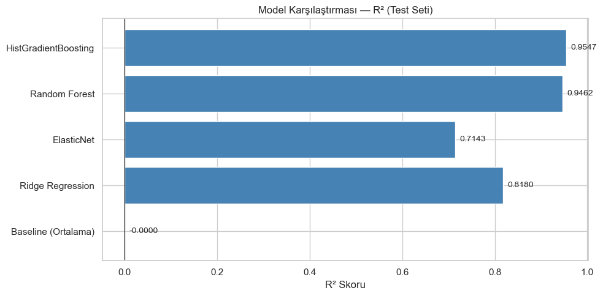

```python
r2_vals = [r["R2"] for r in results]
model_names = [r["model"] for r in results]

fig, ax = plt.subplots(figsize=(10, 5))
colors = ["grey" if v < 0 else "steelblue" for v in r2_vals]
bars = ax.barh(model_names, r2_vals, color=colors, edgecolor="white")
ax.set_xlabel("R² Skoru")
ax.set_title("Model Karşılaştırması — R² (Test Seti)")
ax.axvline(0, color="black", linewidth=0.8)
for bar, val in zip(bars, r2_vals):
    ax.text(bar.get_width() + 0.01, bar.get_y() + bar.get_height()/2,
            f"{val:.4f}", va="center", fontsize=10)
plt.tight_layout()
plt.show()
```

### Cross-Validation: En iyi modelin (HistGradientBoosting) 5-Fold CV sonuçları

```python
best_pipe = Pipeline([
    ("preprocessor", preprocessor),
    ("model", HistGradientBoostingRegressor(max_iter=500, max_depth=8,
                                            learning_rate=0.05, random_state=42)),
])

cv_r2 = cross_val_score(best_pipe, X, y, cv=5, scoring="r2", n_jobs=-1)
cv_mae = -cross_val_score(best_pipe, X, y, cv=5, scoring="neg_mean_absolute_error", n_jobs=-1)

print("5-Fold Cross-Validation Sonuçları (HistGradientBoosting):")
print(f"  R²  : {cv_r2.mean():.4f} ± {cv_r2.std():.4f}  (fold'lar: {np.round(cv_r2, 4)})")
print(f"  MAE : {cv_mae.mean():,.0f} ± {cv_mae.std():,.0f}  (fold'lar: {np.round(cv_mae, 0)})")
```

```
5-Fold Cross-Validation Sonuçları (HistGradientBoosting):
  R²  : 0.9509 ± 0.0037  (fold'lar: [0.9553 0.9515 0.9472 0.9542 0.9461])
  MAE : 67,810 ± 2,168  (fold'lar: [65646. 66931. 71699. 66256. 68519.])
```

## 10. Özellik Önemi ve Hata Analizi

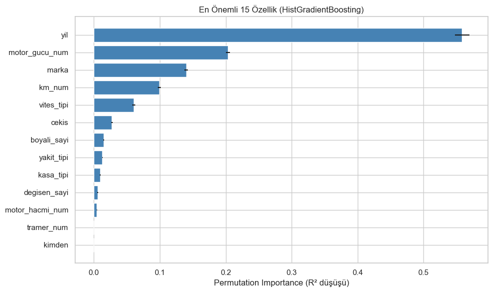

|  | feature | importance_mean | importance_std |
| --- | --- | --- | --- |
| 0 | yil | 0.558576 | 0.010756 |
| 3 | motor_gucu_num | 0.203227 | 0.003090 |
| 7 | marka | 0.140108 | 0.002530 |
| 1 | km_num | 0.099568 | 0.002328 |
| 8 | vites_tipi | 0.060430 | 0.002344 |
| 11 | cekis | 0.027394 | 0.001145 |
| 4 | boyali_sayi | 0.014742 | 0.000843 |
| 9 | yakit_tipi | 0.012968 | 0.000511 |
| 10 | kasa_tipi | 0.009711 | 0.000525 |
| 5 | degisen_sayi | 0.005739 | 0.000520 |
| 2 | motor_hacmi_num | 0.004593 | 0.000262 |
| 6 | tramer_num | 0.000053 | 0.000074 |
| 12 | kimden | 0.000017 | 0.000052 |

```python
from sklearn.inspection import permutation_importance

best_pipe.fit(X_train, y_train)

perm_imp = permutation_importance(best_pipe, X_test, y_test,
                                   n_repeats=10, random_state=42, n_jobs=-1)

feat_names = numeric_features + categorical_features
imp_df = pd.DataFrame({
    "feature": feat_names,
    "importance_mean": perm_imp.importances_mean,
    "importance_std": perm_imp.importances_std,
}).sort_values("importance_mean", ascending=False)

fig, ax = plt.subplots(figsize=(10, 6))
top_n = imp_df.head(15)
ax.barh(top_n["feature"], top_n["importance_mean"],
        xerr=top_n["importance_std"], color="steelblue", edgecolor="white")
ax.set_xlabel("Permutation Importance (R² düşüşü)")
ax.set_title("En Önemli 15 Özellik (HistGradientBoosting)")
ax.invert_yaxis()
plt.tight_layout()
plt.show()

imp_df.head(15)
```

### Hata Analizi: Gerçek vs Tahmin

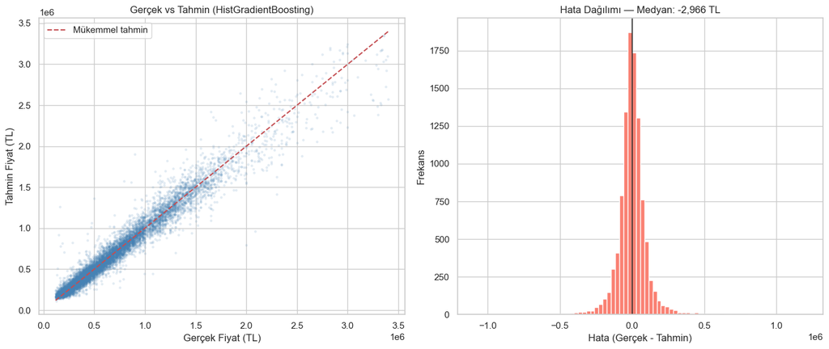

```python
y_pred_best = best_pipe.predict(X_test)

fig, axes = plt.subplots(1, 2, figsize=(14, 6))

axes[0].scatter(y_test, y_pred_best, alpha=0.1, s=5, color="steelblue")
mn, mx = y_test.min(), y_test.max()
axes[0].plot([mn, mx], [mn, mx], "r--", linewidth=1.5, label="Mükemmel tahmin")
axes[0].set_xlabel("Gerçek Fiyat (TL)")
axes[0].set_ylabel("Tahmin Fiyat (TL)")
axes[0].set_title("Gerçek vs Tahmin (HistGradientBoosting)")
axes[0].legend()

errors = y_test - y_pred_best
axes[1].hist(errors, bins=80, color="salmon", edgecolor="white")
axes[1].axvline(0, color="black", linewidth=1)
axes[1].set_xlabel("Hata (Gerçek - Tahmin)")
axes[1].set_ylabel("Frekans")
axes[1].set_title(f"Hata Dağılımı — Medyan: {np.median(errors):,.0f} TL")

plt.tight_layout()
plt.show()
```

```python
error_df = X_test.copy()
error_df["gercek_fiyat"] = y_test.values
error_df["tahmin_fiyat"] = y_pred_best
error_df["hata"] = error_df["gercek_fiyat"] - error_df["tahmin_fiyat"]
error_df["abs_hata"] = error_df["hata"].abs()

print("=== En kötü 10 tahmin (en yüksek mutlak hata) ===")
worst = error_df.nlargest(10, "abs_hata")[
    ["marka", "yil", "km_num", "motor_gucu_num", "gercek_fiyat", "tahmin_fiyat", "hata"]
]


def _fmt_tl(x):
    """TL tutarını bilimsel gösterim olmadan yaz (örn. 1.234.567 TL)."""
    if pd.isna(x):
        return ""
    return f"{int(round(float(x))):,}".replace(",", ".") + " TL"


def _fmt_sayi(x):
    """km / hp gibi sayıları noktalı binlik ayırıcıyla göster."""
    if pd.isna(x):
        return ""
    return f"{int(round(float(x))):,}".replace(",", ".")


worst_goster = worst.copy()
worst_goster["km_num"] = worst_goster["km_num"].apply(_fmt_sayi)
worst_goster["motor_gucu_num"] = worst_goster["motor_gucu_num"].apply(_fmt_sayi)
for col in ["gercek_fiyat", "tahmin_fiyat", "hata"]:
    worst_goster[col] = worst[col].apply(_fmt_tl)

worst_goster
```

```
=== En kötü 10 tahmin (en yüksek mutlak hata) ===
```

|  | marka | yil | km_num | motor_gucu_num | gercek_fiyat | tahmin_fiyat | hata |
| --- | --- | --- | --- | --- | --- | --- | --- |
| 41063 | Volkswagen | 2007 | 320.000 | 225 | 1.999.999 TL | 793.349 TL | 1.206.650 TL |
| 47656 | Mercedes - Benz | 1997 | 187.000 | 231 | 2.090.000 TL | 960.450 TL | 1.129.550 TL |
| 41039 | Regal Raptor | 2023 | 6.000 |  | 165.000 TL | 1.259.504 TL | -1.094.504 TL |
| 40958 | BMW | 2004 | 167.000 | 272 | 900.000 TL | 1.903.714 TL | -1.003.714 TL |
| 43702 | Volkswagen | 2020 | 13.000 | 120 | 3.300.000 TL | 2.386.544 TL | 913.456 TL |
| 42063 | Mercedes - Benz | 1998 | 389.000 | 238 | 2.300.000 TL | 1.416.552 TL | 883.448 TL |
| 32884 | Volvo | 2002 | 202.000 | 272 | 500.000 TL | 1.365.892 TL | -865.892 TL |
| 46358 | Audi | 2019 | 179.000 | 213 | 3.397.500 TL | 2.576.233 TL | 821.267 TL |
| 12924 | Skoda | 2024 | 15.000 | 138 | 3.325.000 TL | 2.506.657 TL | 818.343 TL |
| 7388 | Mercedes - Benz | 2013 | 190.000 | 263 | 3.295.000 TL | 2.485.036 TL | 809.964 TL |

## 11. Tekil Araç Fiyat Tahmini

**Hemen alttaki kod hücresini** çalıştırın. `ornek_arac` sözlüğünü kendi aracınıza göre düzenleyin. Kategorik alanlar (`marka`, `vites_tipi`, vb.) eğitim verisinde geçen değerlerle **aynı yazım** olmalıdır (büyük/küçük harf dahil). Sayısal alanlar modelde kullandığımız parse edilmiş birimlerle uyumludur: km, motor cc, hp.

```python
def fmt_tl_cikti(tutar_tl):
    """Tahmin çıktısını okunaklı TL stringine çevirir."""
    return f"{int(round(float(tutar_tl))):,}".replace(",", ".") + " TL"


def arac_fiyat_tahmini(
    yil,
    km_num,
    motor_hacmi_num,
    motor_gucu_num,
    marka,
    vites_tipi="Otomatik",
    yakit_tipi="Benzin",
    kasa_tipi="Sedan",
    cekis="Önden Çekiş",
    kimden="Galeriden",
    boyali_sayi=0.0,
    degisen_sayi=0.0,
    tramer_num=0.0,
):
    """
    Eğitilmiş best_pipe ile tahmin. Kategorik değerler veri setindeki etiketlerle aynı yazılmalı.
    """
    satir = {
        "yil": int(yil),
        "km_num": float(km_num),
        "motor_hacmi_num": float(motor_hacmi_num) if motor_hacmi_num is not None else np.nan,
        "motor_gucu_num": float(motor_gucu_num) if motor_gucu_num is not None else np.nan,
        "boyali_sayi": float(boyali_sayi),
        "degisen_sayi": float(degisen_sayi),
        "tramer_num": float(tramer_num),
        "marka": marka,
        "vites_tipi": vites_tipi,
        "yakit_tipi": yakit_tipi,
        "kasa_tipi": kasa_tipi,
        "cekis": cekis,
        "kimden": kimden,
    }
    X_new = pd.DataFrame([satir])[numeric_features + categorical_features]
    return float(best_pipe.predict(X_new)[0])


# --- Burayı düzenleyin ---
ornek_arac = {
    "yil": 2004,
    "km_num": 185_000,
    "motor_hacmi_num": 2000,
    "motor_gucu_num": 150,
    "marka": "BMW",
    "vites_tipi": "Otomatik",
    "yakit_tipi": "LPG & Benzin",
    "kasa_tipi": "Sedan",
    "cekis": "Önden Çekiş",
    "kimden": "Galeriden",
    "boyali_sayi": 2,
    "degisen_sayi": 1,
    "tramer_num": 40000,
}

tahmin = arac_fiyat_tahmini(**ornek_arac)
print("Tahmini fiyat:", fmt_tl_cikti(tahmin))
print("\nİpucu — veri setinde geçen markalar (ilk 30):")
print(sorted(dfm["marka"].unique())[:30])
```

```
Tahmini fiyat: 602.216 TL

İpucu — veri setinde geçen markalar (ilk 30):
['Alfa Romeo', 'Anadol', 'Audi', 'BMW', 'BYD', 'Cadillac', 'Chery', 'Chevrolet', 'Chrysler', 'Citroen', 'Cupra', 'DS Automobiles', 'Dacia', 'Daewoo', 'Daihatsu', 'Fiat', 'Ford', 'Geely', 'Honda', 'Hyundai', 'Ikco', 'Infiniti', 'Jaguar', 'Kia', 'Lada', 'Lancia', 'MG', 'Maserati', 'Mazda', 'Mercedes -…
```

## 12. Sonuç ve Değerlendirme

**Proje Özeti:**

- ~52.000 ikinci el araç ilanından oluşan veri seti üzerinde araç fiyat tahmini regresyon problemi çözüldü.
- 23 ham sütundan 7 sayısal + 6 kategorik özellik seçildi ve ön işleme pipeline'ı oluşturuldu.
- 5 farklı model karşılaştırıldı: Baseline, Ridge, ElasticNet, Random Forest, HistGradientBoosting.

**Sınırlamalar:**

- `seri` ve `model` sütunlarının yüksek kardinalitesi nedeniyle hariç tutuldu; Target Encoding ile dahil edilmesi performansı artırabilir.
- `tramer` sütunu %90 eksik; daha zengin tramer verisi modeli güçlendirebilir.
- `konum` bilgisinden il çıkarılarak bölgesel fiyat farkları modellenebilir.
- Hiperparametre optimizasyonu (GridSearch / Optuna) yapılmadı; ek iyileştirme potansiyeli var.